# Taller gráficos

# Gráficos.

En los puntos que siguen se propone hacer gráficos para visualizar la información que tiene la base “estudiantes2”. Construya los gráficos lo mejor posible dado que la edición de los mismos se tendrá en cuenta a la hora de evaluar esta parte del taller. Los gráficos deben ser claros para cualquier lector, por ejemplo, deben tener un titulo, nombres en los ejes y todo lo que ustedes consideren necesario para comprender la información.

6. (12 puntos) Utilizando la libreria base y ggplo2 construya un histograma para la variable “interdisciplinar”. Describa que observa en el comportamiento de ésta variable y comente acerca de la libreria que más le gusto para hacer el gráfico.

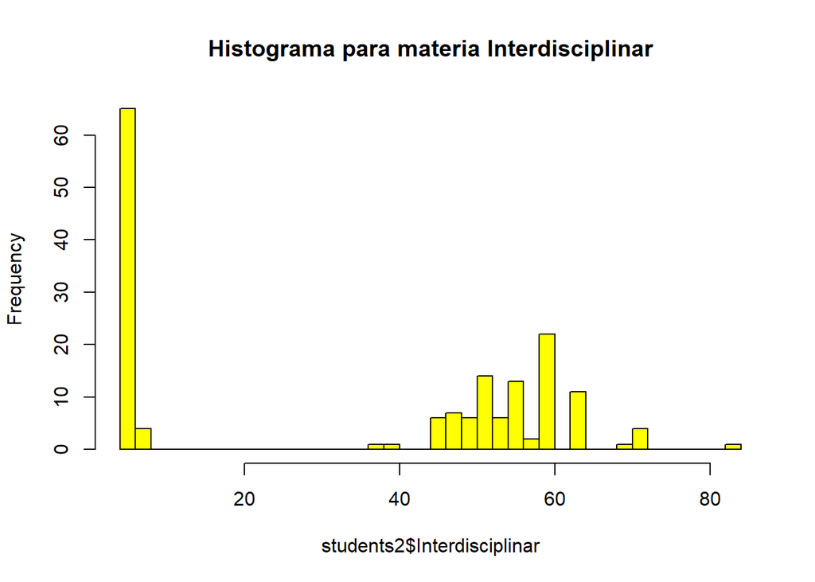

```r
library(ggplot2)
hist(students2$Interdisciplinar, breaks=50, col="yellow", main="Histograma para materia Interdisciplinar" )
```

7. (12 puntos) Utilizando la libreria que prefiera construya un gráfico donde se muestre la función de densidad de la variable “Matemáticas” por “Género”. Haga una interpretación del gráfico.

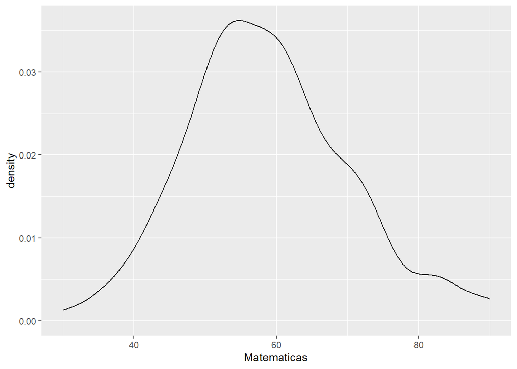

```r
library(ggplot2)
library(tidyverse)
ggplot(students2) + aes(x=Matematicas) + geom_density()
```

8. (12 puntos) Utilizando la libreria que prefiera construya un diagrama circular donde muestre el porcentaje de estudiantes que presentaron la prueba por programa. Haga una interpretación del gráfico.

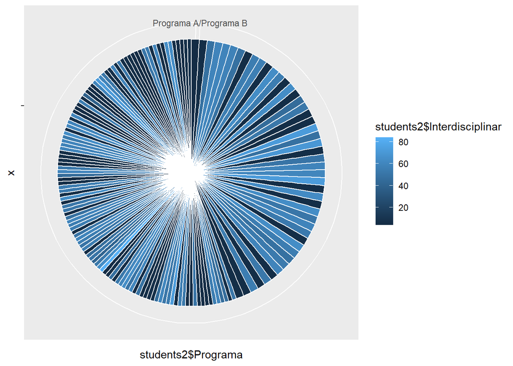

```r
library(ggplot2)
library(tidyverse)
ggplot(students2,aes(x="",y=students2$Programa, fill=students2$Interdisciplinar))+
  geom_bar(stat = "identity",color="white")+
  coord_polar(theta="y")
```

9. (12 puntos)Construya un gráfico que le permita comparar ver como se comporta la variable “Matemáticas” por “Programa”. Interprete lo que observa.

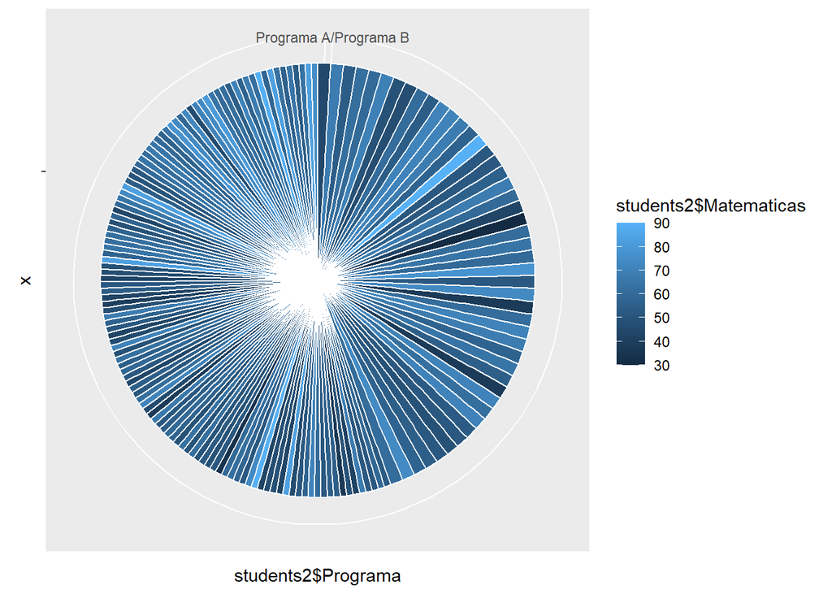

```r
library(ggplot2)
library(tidyverse)
ggplot(students2,aes(x="",y=students2$Programa, fill=students2$Matematicas))+
  geom_bar(stat = "identity",color="white")+
  coord_polar(theta="y")
```

10. (12 puntos) Construya un boxplot a partir del cual pueda comparar la variable “Matemáticas” con las demás materias. Incluya la media de cada materia en el gráfico. Describa lo que observa en la gráfica.

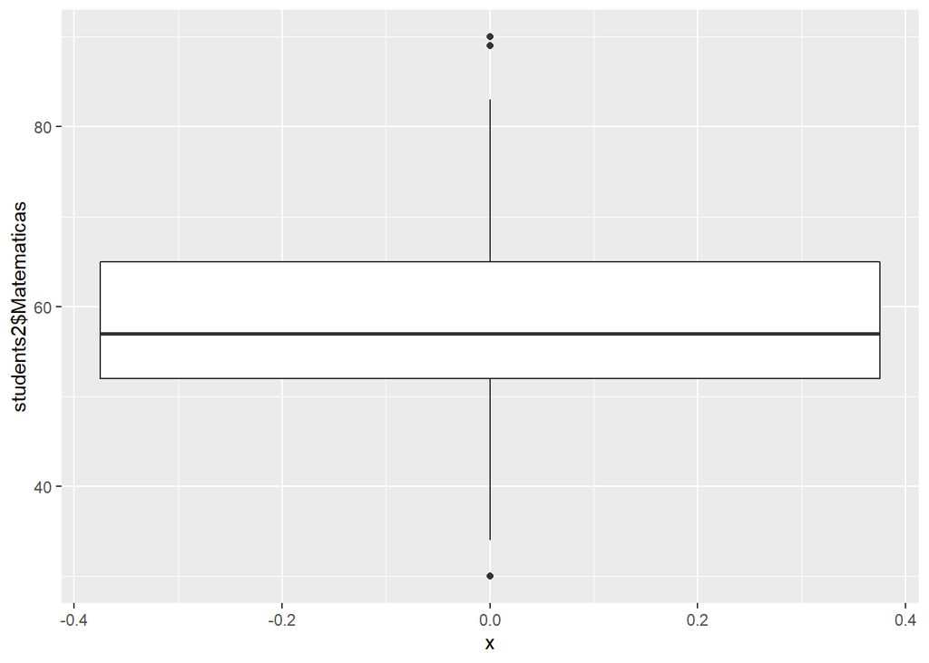

```r
library(ggplot2)
library(tidyverse)
ggplot(students2, aes(x=0, y=students2$Matematicas)) + geom_boxplot()
```

11. (12 puntos) Construya un diagrama de barras apiladas para ver el tipo de programa por ciudad. Interprete el gráfico

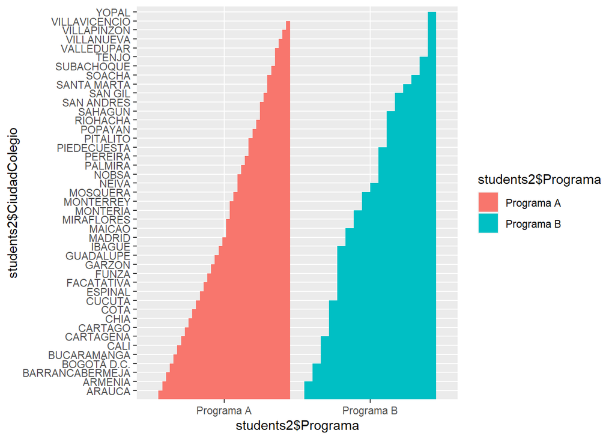

```r
library(ggplot2)
library(tidyverse)
ggplot(data=students2, aes(x=students2$Programa, y=students2$CiudadColegio, fill=students2$Programa)) +
    geom_bar(stat="identity", position="dodge")
```

12. (12 puntos) Construya un un gráfico que le permita comparar el comportamineto de la variable “Matemáticas” para los colegios ubicados en los municipios de CHIA y FACATATIVA.

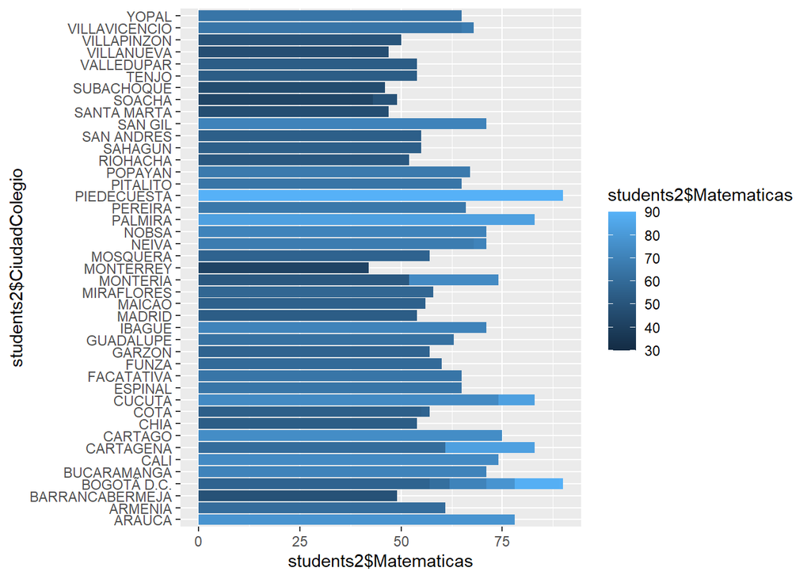

```r
library(ggplot2)
library(tidyverse)
ggplot(data=students2, aes(x=students2$Matematicas, y=students2$CiudadColegio, fill=students2$Matematicas)) +
    geom_bar(stat="identity", position="dodge")
```